# Lab 7

Chau Nguyen

2/16/2022

## Summarizing Missing Data

Weight is the only variable that has missing values. Additionally, there are 1796 observations that have missing values.

```
## # A tibble: 1 × 7
##    trip  mark length weight  year section species
##   <int> <int>  <int>  <int> <int>   <int>   <int>
## 1     0     0      0   1796     0       0       0
```

# Task 2 – Visualizing Missing Data

Unfortunately, these missing values are not for only one year, trip, or section of river.

Create a thoughtful visualization exploring the frequency of missing values across the different years, sections, and trips.

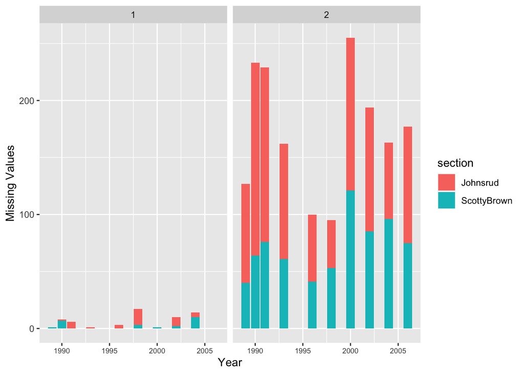

The function should take a single vector as its input. The function should return the rescaled vector. Think about the “efficiency” of your function. Are you calling the same function multiple times?

```r
rescale_01 <- function(x){
  rng <- range(x, na.rm = TRUE)
  (x - rng[1]) / (rng[2] - rng[1])
}
```

Task 3 - Performing a Simple Test First, test your function on a simple vector. Verify that the maximum of your rescaled vector is 1 and the minimum is 0!

```
##  [1] 0.00000000 0.04166667 0.08333333 0.12500000 0.16666667 0.20833333
##  [7] 0.25000000 0.29166667 0.33333333 0.37500000 0.41666667 0.45833333
## [13] 0.50000000 0.54166667 0.58333333 0.62500000 0.66666667 0.70833333
## [19] 0.75000000 0.79166667 0.83333333 0.87500000 0.91666667 0.95833333
## [25] 1.00000000         NA
```

Task 4 - Performing a More Difficult Test Next, let’s test the function on the length column of the BlackfootFish dataset.

Make side-by-side plots of the original values of length and the rescaled values of length. Hint: The gridExtra package has a grid.arrange() function that allows for you to arrange multiple ggplot() objects into rows and columns. Or, you can play around with the fig.show and out.width options of your code chunk (https://bookdown.org/yihui/rmarkdown-cookbook/figures-side.html).

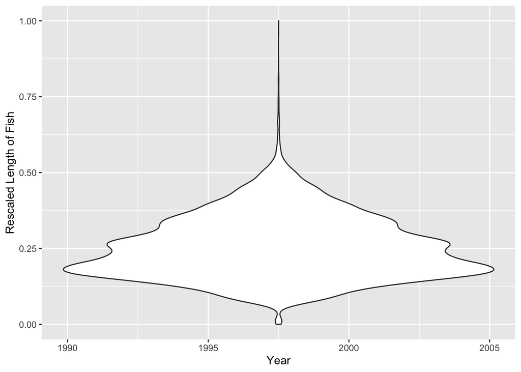

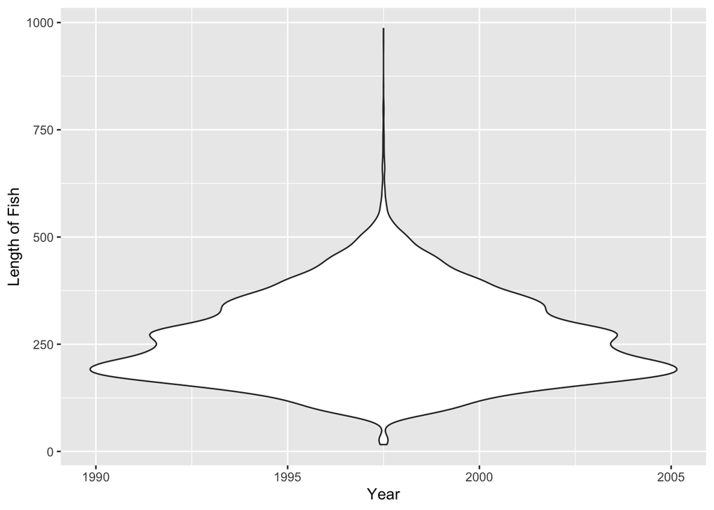

Task 5 – Incorportaing Variables Suppose you would for your rescale() function to perform operations on a variable within a dataset. Ideally, your function would take a dataframe and a variable name as inputs and return a dataframe where the variable has been rescaled.

Create a rescale_column() that accepts two arguments, (1) a dataframe, and (2) the name(s) of the variable(s) to be rescaled. The body of the function should call the original rescale_01() function you wrote previously.

Task 6 – Another Function Test Alright, now let’s put your rescale_column() function to work! Use your rescale_column() function to rescale both the length and weight columns.

I expect that you only call the rescale() function one time!

```
## # A tibble: 18,352 × 8
##     trip  mark length  weight  year section  species length_rescaled
##    <dbl> <dbl>  <dbl>   <dbl> <dbl> <chr>    <chr>             <dbl>
##  1     1     0  0.280 0.0374   1989 Johnsrud RBT               0.280
##  2     1     0  0.280 0.0406   1989 Johnsrud RBT               0.280
##  3     1     0  0.277 0.0524   1989 Johnsrud RBT               0.277
##  4     1     0  0.315 0.0588   1989 Johnsrud RBT               0.315
##  5     1     0  0.305 0.0641   1989 Johnsrud RBT               0.305
##  6     1     0  0.358 0.0812   1989 Johnsrud RBT               0.358
##  7     1     0  0.261 0.0363   1989 Johnsrud RBT               0.261
##  8     1     0  0.148 0.00855  1989 Johnsrud RBT               0.148
##  9     1     0  0.203 0.0171   1989 Johnsrud RBT               0.203
## 10     1     0  0.145 0.00748  1989 Johnsrud RBT               0.145
## # … with 18,342 more rows
```

[output not shown]